# Population Genomics Capstone Project

Xenidis Vasileios

2023-07-07

# Introduction

The environmental conditions play a crucial role in the evolution of species. Hence, through time, natural populations tend to diversify in different geographical landscapes (Raeymaekers et al. 2017). Otherwise, if the rate of adaptability is low, then the danger of species extinction rises (Kemppainen et al. 2021). Adapting to environmental changes requires either novel mutations or heritable variation, with the latter being the fastest way to adapt to the local environment (Kemppainen et al. 2021). Populations sharing the same genetic pool of alleles may develop similar forms (parallel evolution), when exposed to analogous environmental conditions, provided that there are no founder events or random genetic drift. In the latter cases, even if advantageous genetic variants occur, they can be lost due to the reduced likelihood of the variants to mate with the local population. Thus, in case these events should occur, adaptation remains unlikely (Kemppainen et al. 2021).

In order to better understand geographically-based biodiversity patterns it is important to quantify the variability of evolutionary potential (Raeymaekers et al. 2017). It has been observed, through the use of genomic tools, that species living in common landscapes may have different evolutionary potential (Raeymaekers et al. 2017).

Local adaptation is the process according to which, certain beneficial traits are present in the local population and lead to better adaptation to the local environmental conditions (eg. higher survival and reproduction chances) (Meek et al. 2023).

Adaptive divergence is the process where new species variations arise from a shared common ancestor due to their ability to adapt to different environmental conditions. By adapting to different environmental conditions, populations can become genetically and phenotypically distinct from each other. This eventually leads to the development of new subpopulations and potentially species (Tusso et al. 2021)

# Research questions

- Do habitat conditions affect body weight?
- Do habitat conditions affect body length?
- Are there in site variations in the same habitat for body weight? What about body length?
- Do habitat conditions affect each sex differently?
- Do the environmental parameters (eg.mean temperature ) affect body weight and body length based on each habitat?

# Methods

## Fish species:

The dataset is part of the Raeymaekers et al. (2017). The dataset contains 192 samples from (Gasterosteus Aculeatus Linnaeus, 1758) individuals (three-spined stickleback) that have been isolated from various coastal lowland sites in Belgium and Netherlands. There are eight populations from brackish and freshwater habitats. Individuals that belong to the brackish water habitat have been isolated from the L01, L02, L03, L05 sites whereas those that belong to the freshwater habitat have been isolated from the L07, L09, L10, L12 sites. From each site approximately 24 individuals have been sequenced using whole genome sequencing. The produced data were organized based on the chromosomes of each individual. The reference genome that was used in the analysis was downloaded from the Stickleback genome browser site (https://stickleback.genetics.uga.edu/) and the file used was threespine stickleback genome assembly v. 5.

## Bioinformatics:

Monomorphic SNPs have been filtered to exclude all sites at which no alternative alleles are called for any of the samples and all sites at which only alternative alleles are called (all samples differ from the reference genome). Furthermore, multiallelic and low allele frequency (AF < 0.01) SNPs have also been removed.

An analysis pipeline was created in order to conduct a population genomic analysis using the above dataset. In the present analysis, chromosome X was used. Hence, the first step was to isolate chromosome X from the rest of the dataset using GNU/Linux commands. Afterwards, the R package vcfR was used for the visualization of the raw VCF data. Variants in raw VCF files were then subjected to extensive filtering based on the quality scores to reduce the number of low-quality SNPs.

Chromosome plots were produced using the vcfR package and chromoqc function in R (version 4.2.2) from Knaus et al. (2017). The next step was to convert the ploidy of genotypes into binary code using the library adagenet. In order to graphically assess the position of the polymorphic sites within a scaffold the snpposi.plot function was used. For the calculation of F-st, p values and bootstraps the StAMPP package was used. Next, the visualization of the genetic differentiation in an unrooted tree using the ape library package was performed. Succeeding this step, as a way of estimating the heterozygosity for each population the adegenet package was used. Last but not least, in order to explain the variation in our data Principal component analysis (PCA) was conducted.

# Library and data

```r
library(DEMEtics)
library(StAMPP)
```

```r
library(gridExtra)
library(readr)
library(ggplot2)
library(vcfR)
library(ape)
library(adegenet)
#read the data into R:
vcfdata <- read.vcfR("ChromosomeX.vcf")
SampleInfo <- read.table(file = "SamplesInfo.txt", sep = "\t", header=TRUE)
SitesInfo <- read.table(file = "SitesInfo.txt", sep = "\t", header=TRUE)
SitesInfo_new <- read.table(file = "SitesInfo_new.txt", sep = "\t", header=TRUE)
```

# Chromoplots, Visual representation of SNPs

## Plots, table

```r
# this shows the alleles for the first 10 SNPs
vcfdata@fix[1:10,1:5]

# This reads in the underlying genome file
dna_file <- read.dna("stickleback_v5_assembly.fa",format="fasta")

# This function combines the sequence and variation information
chrom <- create.chromR(name="ChromX", vcf=vcfdata, seq=dna_file, verbose=TRUE)
```

[output not shown]

```
## DNAbin object includes more than one chromosome.
```

```
## chrI, chrII, chrIII, chrIV, chrIX, chrM, chrUn, chrV, chrVI, chrVII, chrVIII, chrX, chrXI, chrXII, chrXIII, chrXIV, chrXIX, chrXV, chrXVI, chrXVII, chrXVIII, chrXX, chrXXI, chrY
```

```
## Subsetting to the first chromosome
```

```
## Names in vcf:
```

```
##   chrX
```

```
## Names of sequences:
```

```
##   chrI
```

```
## Initializing var.info slot.
```

```
## var.info slot initialized.
```

```r
# # This function calls several helper functions to process the variant,
# sequence and  annotation data for visualization. Choosing win.size=10
# summarizes the data over 10bp windows
chrom <- proc.chromR(chrom, verbose = TRUE,win.size=10)
```

```
## Nucleotide regions complete.
```

```
##   elapsed time:  11.88
```

```
## N regions complete.
```

```
##   elapsed time:  11.62
```

```
## Population summary complete.
```

```
##   elapsed time:  28.78
```

```
## window_init complete.
```

```
##   elapsed time:  0.04
```

```
## windowize_fasta complete.
```

```
##   elapsed time:  2.19
```

```
## windowize_variants complete.
```

```
##   elapsed time:  0.03
```

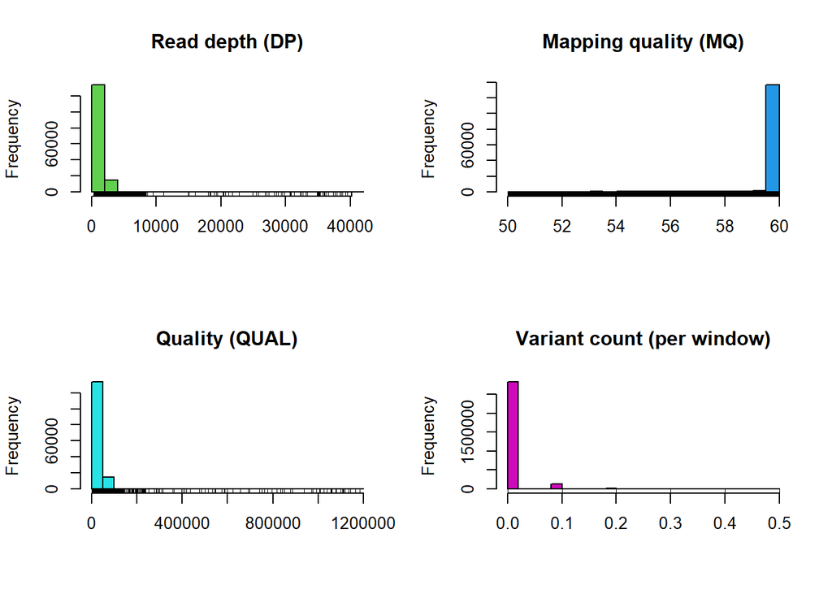

```r
#Plot
plot(chrom)
```

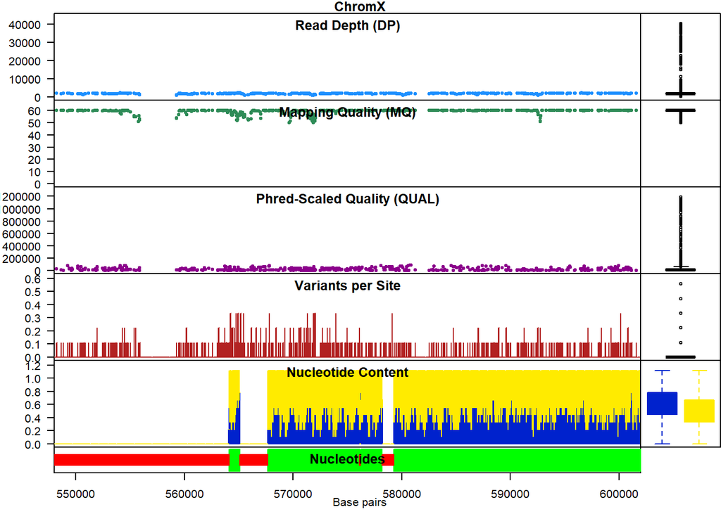

```r
#chromo-plot plus options to be more readable
chromoqc(chrom,xlim=c(5.5e+05, 6e+05))
```

### Allele depths

To plot allele distribution and extract its depths for each sample

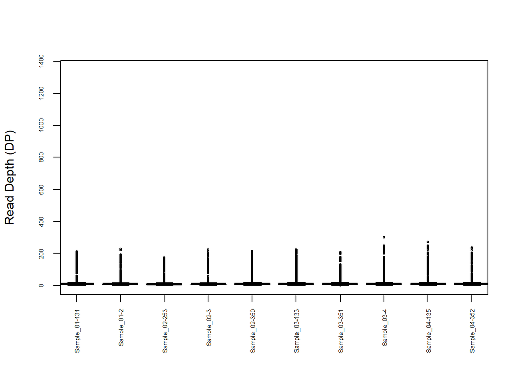

```r
#2nd plot read depth distribution per individual

dp <- extract.gt(vcfdata, element='DP', as.numeric=TRUE)

boxplot(dp, las=3, col=c("#C0C0C0", "#808080"), ylab="Read Depth (DP)", cex=0.4, cex.axis=0.5,xlim=c(1,10))
```

### GENLIGHT objects

Afterwards, vcf data are converted to genlight.data. This is an object that allows other functions to be used from other packages.

```r
#Next step-GENLIGHT objects
genlight.data <- vcfR2genlight(vcfdata)

# Content of a genlight object:
getClassDef("genlight")
```

```
## Class "genlight" [package "adegenet"]
##
## Slots:
##
## Name:           gen        n.loc    ind.names    loc.names      loc.all
## Class:         list      integer   charOrNULL   charOrNULL   charOrNULL
##
## Name:    chromosome     position       ploidy          pop       strata
## Class: factorOrNULL    intOrNULL    intOrNULL factorOrNULL     dfOrNULL
##
## Name:     hierarchy        other
## Class:   formOrNULL         list
```

```r
#individual names
indNames(genlight.data)
```

```
##   [1] "Sample_01-131" "Sample_01-2"   "Sample_02-253" "Sample_02-3"
##   [5] "Sample_02-350" "Sample_03-133" "Sample_03-351" "Sample_03-4"
##   [9] "Sample_04-135" "Sample_04-352" "Sample_04-5"   "Sample_05-138"
##  [13] "Sample_05-353" "Sample_06-139" "Sample_06-257" "Sample_07-141"
##  [17] "Sample_07-258" "Sample_07-355" "Sample_08-259" "Sample_09-357"
##  [21] "Sample_10-152" "Sample_10-358" "Sample_12-158" "Sample_12-263"
##  [25] "Sample_13-264" "Sample_13-361" "Sample_14-23"  "Sample_14-265"
##  [29] "Sample_14-362" "Sample_15-363" "Sample_16-164" "Sample_16-25"
##  [33] "Sample_16-267" "Sample_16-364" "Sample_17-1"   "Sample_17-365"
##  [37] "Sample_18-12"  "Sample_18-269" "Sample_18-366" "Sample_19-13"
##  [41] "Sample_20-15"  "Sample_20-172" "Sample_20-271" "Sample_21-29"
##  [45] "Sample_22-31"  "Sample_23-176" "Sample_23-274" "Sample_24-275"
##  [49] "Sample_26-179" "Sample_26-277" "Sample_26-35"  "Sample_27-180"
##  [53] "Sample_27-36"  "Sample_27-375" "Sample_28-376" "Sample_29-182"
##  [57] "Sample_29-280" "Sample_29-38"  "Sample_30-183" "Sample_30-39"
```

[output cut: 33 more lines]

```r
# number of SNPs
nLoc(genlight.data)
```

```
## [1] 148920
```

```r
#We add information about the diploidy of stickleback in 192 samples.
ploidyvalues <- rep(2,192)
ploidy(genlight.data) <- ploidyvalues
```

# Brackish vs Freshwater analysis

In order to compare brackish vs freshwater we should add into pops, the site column and transfer these data into genlight.data.

```r
pops<- as.factor(c(SampleInfo$Site))
pop(genlight.data) <- pops
as.matrix(genlight.data)[20:30,1:5]
```

[output not shown]

A graphical overview of alternative alleles and missing data (in white) can be obtained with the glPlot function:

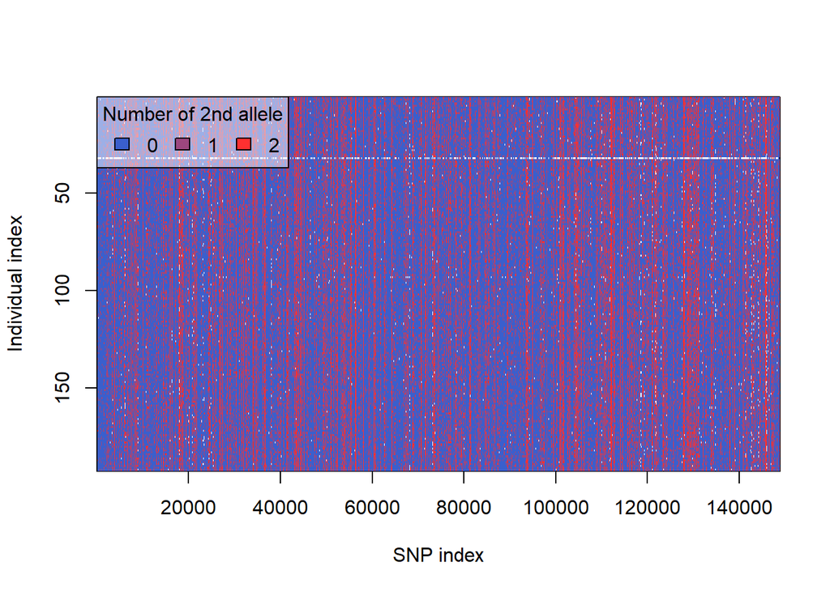

```r
glPlot(genlight.data, posi="topleft")
```

The following graph depicts the position of the polymorphic sites within a chromosome

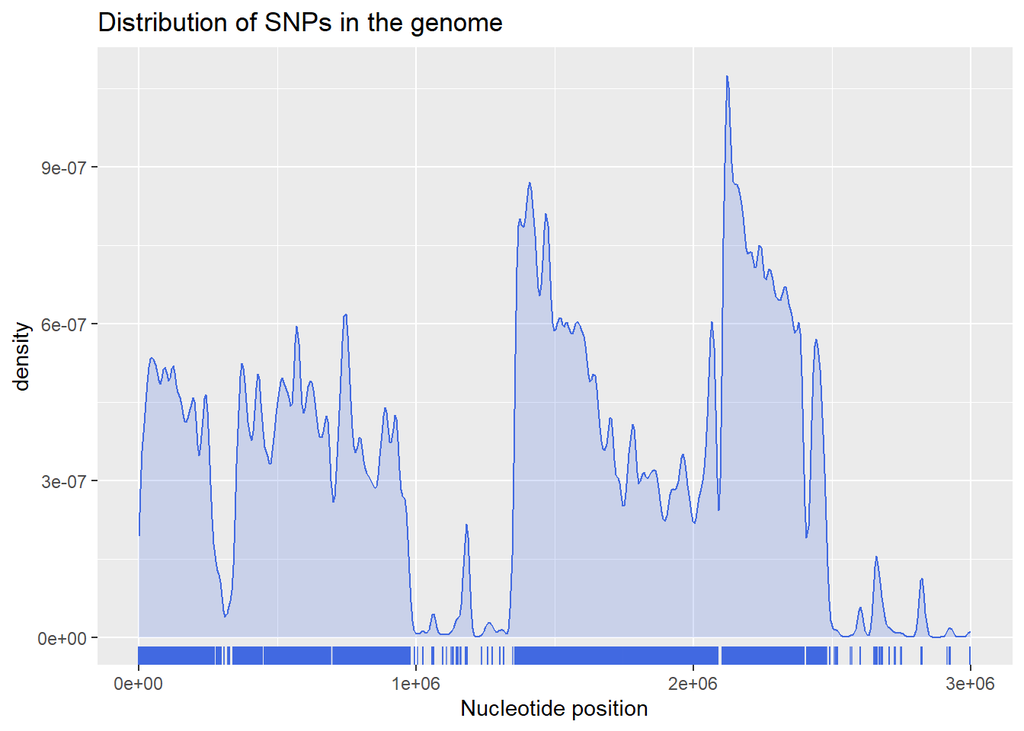

```r
snpposi.plot(position(genlight.data[,genlight.data$chromosome=="chrX"]),genome.size=3000000,codon=FALSE)
```

### Allele frequency spectrum

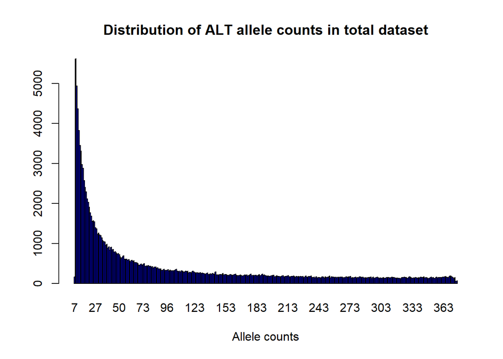

```r
#plot total AFS of the dataset
mySum <- glSum(genlight.data, alleleAsUnit = TRUE)
barplot(table(mySum), col="blue", space=0, xlab="Allele counts",
main="Distribution of ALT allele counts in total dataset")
```

# Body length ~ habitat

### Mean and median of body length

```r
#Calculate mean body length for each habitat
mean_body_length_brackish <- mean(SampleInfo$Length.cm.[SampleInfo$Site %in% c("L01","L02","L03","L05")])
mean_body_length_Fresh <- mean(SampleInfo$Length.cm.[SampleInfo$Site %in% c("L07","L09","L10","L12")])

#Calculate the median body length for each habitat
median_body_length_brackish <- median(SampleInfo$Length.cm.[SampleInfo$Site %in% c("L01","L02","L03","L05")], na.rm = TRUE)
median_body_length_fresh <- median(SampleInfo$Length.cm.[SampleInfo$Site %in% c("L07","L09","L10","L12")], na.rm = TRUE)
```

### Body length graph

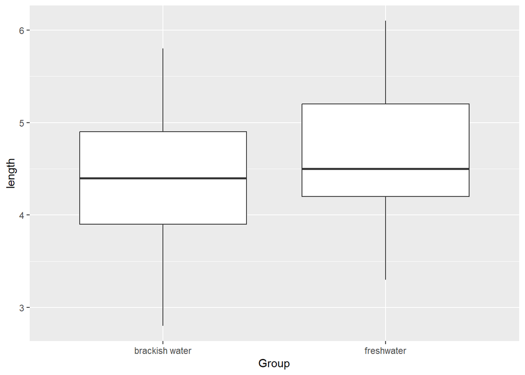

```r
#Visualize into a boxplot for length in cm
brackish_length <-SampleInfo$Length.cm.[SampleInfo$Site %in% c("L01","L02","L03","L05")]
fresh_length  <- SampleInfo$Length.cm.[SampleInfo$Site %in% c("L07","L09","L10","L12")]

#create a dataframe with the group labels and data.
data <- data.frame(
  Group= factor(c(rep("brackish water",length(brackish_length)),rep("freshwater",length(fresh_length)))),
  Value= c(brackish_length,fresh_length)
)

#ggplot2
ggplot(data,aes(x=Group,y=Value)) + geom_boxplot() + ylab("length") + xlab("Group")
```

the graphs show the mean, median and the outliers for body length according to each habitat. From the graphs no visible differences can be seen when comparing body length vs habitat. Hence, the Wilcoxon test was performed, in order to assess if habitat conditions are statistically significant to affect the length of three-spined stickleback.

```r
resultL <- wilcox.test(brackish_length, fresh_length)
print(resultL)
```

```
##
##  Wilcoxon rank sum test with continuity correction
##
## data:  brackish_length and fresh_length
## W = 3801, p-value = 0.03593
## alternative hypothesis: true location shift is not equal to 0
```

The p-value is smaller than 0.05 (p-value=0.03593), thus the result is statistically significant.

## Body weight ~ habitat

### Mean and median of body weight

```r
#Calculate the mean bodyweight for each habitat
mean_body_weight_brackish <- mean(SampleInfo$Body_weight.g.[SampleInfo$Site %in% c("L01","L02","L03","L05")])
mean_body_weight_fresh <- mean(SampleInfo$Body_weight.g.[SampleInfo$Site %in% c("L07","L09","L10","L12")])

#Calculate the median bodyweight for each habitat
median_body_weight_brackish <- median(SampleInfo$Body_weight.g.[SampleInfo$Site %in% c("L01","L02","L03","L05")], na.rm = TRUE)
median_body_weight_fresh <- median(SampleInfo$Body_weight.g.[SampleInfo$Site %in% c("L07","L09","L10","L12")], na.rm = TRUE)
```

### Body weight graph

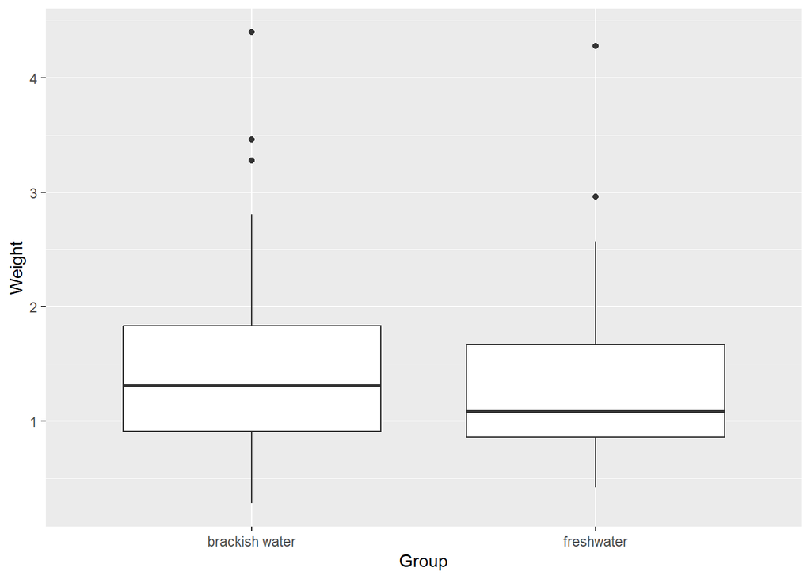

```r
groups <- c("brackish","fresh")
brackishW <- c(SampleInfo$Body_weight.g.[SampleInfo$Site %in% c("L01", "L02", "L03", "L05")])
freshW <- c(SampleInfo$Body_weight.g.[SampleInfo$Site %in% c("L07", "L09", "L10", "L012")])
data <- data.frame(
  Group = factor(c(rep("brackish water", length(brackishW)), rep("freshwater", length(freshW)))),
  Value = c(brackishW, freshW)
)

ggplot(data, aes(x = Group, y = Value)) +
  geom_boxplot() +
  ylab("Weight") +
  xlab("Group")
```

Wilcoxon test was performed, in order to assess if habitat conditions are statistically significant to affect the body weight of three-spined stickleback.

```r
resultW <- wilcox.test(brackishW, freshW)
print(resultW)
```

```
##
##  Wilcoxon rank sum test with continuity correction
##
## data:  brackishW and freshW
## W = 3750, p-value = 0.2869
## alternative hypothesis: true location shift is not equal to 0
```

The p-value is larger than 0.05 (p-value=0.2869), thus accepting the null-hypothesis which states there are no statistically significant differences between bodyweight and habitat

# Genetic differentiantion

## Fst values

```r
#The 148920 number comes from the nloc function, we randomly select 50000
genlight.data.reduced <- genlight.data[,sample(1:148920, 50000)]
genlight.data.reduced #checking basic information
```

```
##  /// GENLIGHT OBJECT /////////
##
##  // 192 genotypes,  50,000 binary SNPs, size: 6.7 Mb
##  93263 (0.97 %) missing data
##
##  // Basic content
##    @gen: list of 192 SNPbin
##    @ploidy: ploidy of each individual  (range: 2-2)
##
##  // Optional content
##    @ind.names:  192 individual labels
##    @loc.names:  50000 locus labels
##    @chromosome: factor storing chromosomes of the SNPs
##    @position: integer storing positions of the SNPs
##    @pop: population of each individual (group size range: 24-24)
##    @other: a list containing: elements without names
```

```r
#Fst values
FstValues <- stamppFst(genlight.data.reduced, nboots = 100, percent = 95)

#Fsts
FstValues$Fsts
```

```
##            L12         L03        L07         L01        L02       L09      L10
## L12         NA          NA         NA          NA         NA        NA       NA
## L03 0.06748215          NA         NA          NA         NA        NA       NA
## L07 0.06264276 0.013635026         NA          NA         NA        NA       NA
## L01 0.06448793 0.007400456 0.01183057          NA         NA        NA       NA
## L02 0.06704444 0.008909248 0.01362174 0.006689352         NA        NA       NA
## L09 0.07124689 0.050743809 0.05206888 0.048055344 0.05067021        NA       NA
## L10 0.14803864 0.162375873 0.16167268 0.159893218 0.16216671 0.1600343       NA
## L05 0.05148493 0.011282473 0.01431683 0.009165587 0.01142696 0.0325226 0.145117
##     L05
## L12  NA
## L03  NA
## L07  NA
## L01  NA
## L02  NA
## L09  NA
## L10  NA
## L05  NA
```

```r
#P values
FstValues$Pvalues
```

```
##     L12 L03 L07 L01 L02 L09 L10 L05
## L12  NA  NA  NA  NA  NA  NA  NA  NA
## L03   0  NA  NA  NA  NA  NA  NA  NA
## L07   0   0  NA  NA  NA  NA  NA  NA
## L01   0   0   0  NA  NA  NA  NA  NA
## L02   0   0   0   0  NA  NA  NA  NA
## L09   0   0   0   0   0  NA  NA  NA
## L10   0   0   0   0   0   0  NA  NA
## L05   0   0   0   0   0   0   0  NA
```

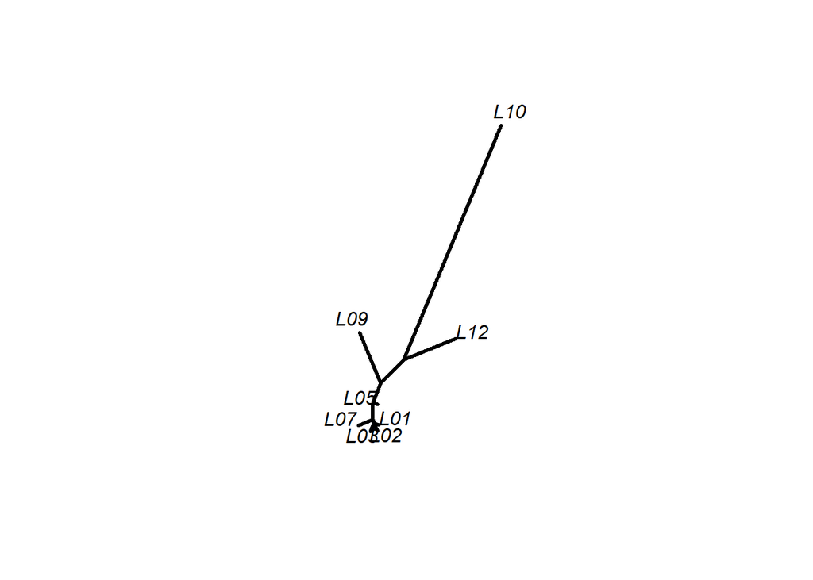

```r
#Population Cluster
Tree <- nj(as.dist(FstValues$Fsts)) # conversion of the Fst values to a tree object

plot.phylo(Tree,type="unrooted",show.tip.label=TRUE,edge.width=3,rotate.tree=90)
add.scale.bar(length = 0.05,lwd=2,x=0.25,y=0.15,col="black")
```

# Heterozygosity + PCA

## Heterozygosity

```r
#Heterozygosity
genind.data <- vcfR2genind(vcfdata)
pops<- as.factor(c(SampleInfo$Site))
pop(genind.data) <- pops
#Then we can apply the Hs function on these data to obtain the average hterozygosity for each pop
Hs(genind.data)
```

```
##       L12       L03       L07       L01       L02       L09       L10       L05
## 0.2081455 0.2232779 0.2237962 0.2254305 0.2229729 0.2149526 0.1746591 0.2251012
```

## PCA

```r
# PCA
pca.1 <- glPca(genlight.data.reduced, nf=2)

pca.1$eig[1]/sum(pca.1$eig) # proportion of variation explained by 1st principal component
```

```
## [1] 0.06495031
```

```r
pca.1$eig[2]/sum(pca.1$eig) # proportion of variation explained by 2nd principal component
```

```
## [1] 0.02870503
```

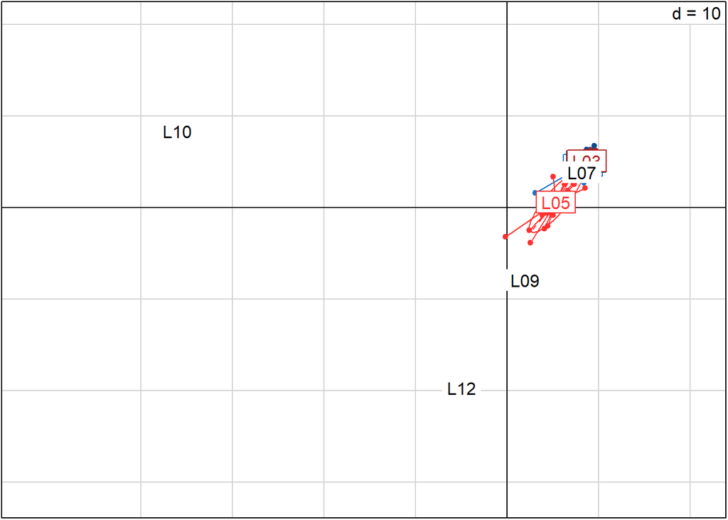

```r
# plot the samples along the first two principle components showing groups
s.class(pca.1$scores, pop(genlight.data.reduced), col=colors()[c(131,132,133,134)])
```

# Do habitat conditions affect each sex differently?

## Visual comparison of sex vs length according to habitat

```r
brackish_length_female <- SampleInfo$Length.cm.[SampleInfo$Site %in% c("L07","L09","L10","L12") & SampleInfo$Sex == "F"]

brackish_length_male <- SampleInfo$Length.cm.[SampleInfo$Site %in% c("L07","L09","L10","L12") & SampleInfo$Sex == "M"]

fresh_length_female  <- SampleInfo$Length.cm.[SampleInfo$Site %in% c("L07","L09","L10","L12") & SampleInfo$Sex == "F"]

fresh_length_male <- SampleInfo$Length.cm.[SampleInfo$Site %in% c("L07","L09","L10","L12") & SampleInfo$Sex == "M"]


# Create a data frame with the necessary columns and values
data <- data.frame(
 Group = factor(c(rep("brackish water (Female)", length(brackish_length_female)), rep("freshwater (Female)", length(fresh_length_female)),
                   rep("brackish water (Male)", length(brackish_length_male)), rep("freshwater (Male)", length(fresh_length_male)))),
  Value = c(brackish_length_female, fresh_length_female, brackish_length_male, fresh_length_male),
  Sex = factor(c(rep("Female", length(brackish_length_female) + length(fresh_length_female)),
                 rep("Male", length(brackish_length_male) + length(fresh_length_male))))
)
```

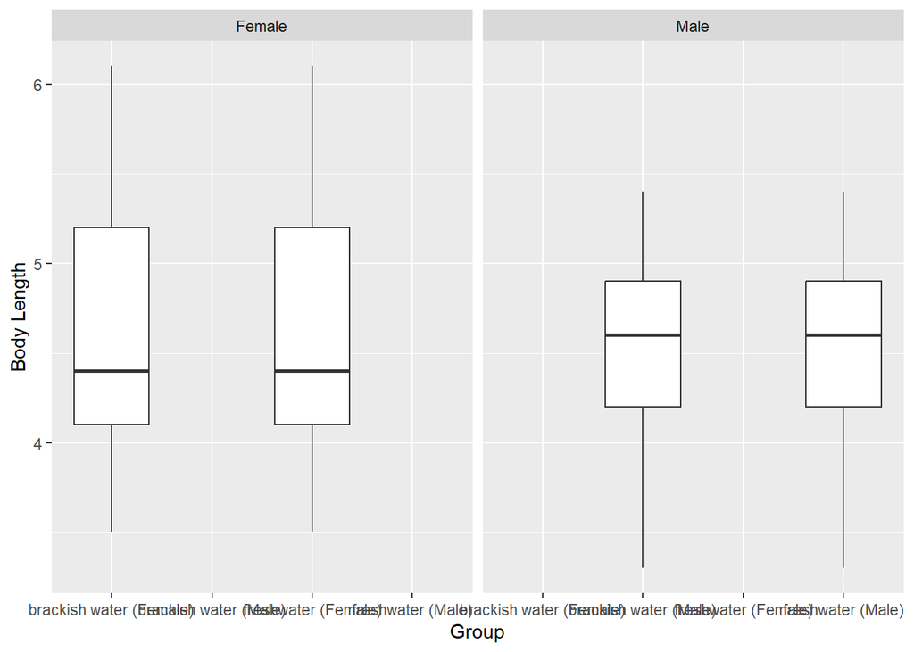

```r
# ggplot2

ggplot(data, aes(x = Group, y =Value)) +
  geom_boxplot() +
  ylab("Body Length") +
  xlab("Group") +
  facet_wrap(~ Sex)
```

## Visual comparison of sex vs bodyweight according to habitat

```r
brackish_bodyweight_female <- SampleInfo$Body_weight.g.[SampleInfo$Site %in% c("L07","L09","L10","L12") & SampleInfo$Sex == "F"]
brackish_bodyweight_male <- SampleInfo$Body_weight.g.[SampleInfo$Site %in% c("L07","L09","L10","L12") & SampleInfo$Sex == "M"]
fresh_bodyweight_female  <- SampleInfo$Body_weight.g.[SampleInfo$Site %in% c("L07","L09","L10","L12") & SampleInfo$Sex == "F"]
fresh_bodyweight_male <- SampleInfo$Body_weight.g.[SampleInfo$Site %in% c("L07","L09","L10","L12") & SampleInfo$Sex == "M"]

# Create a data frame with the necessary columns and values
data <- data.frame(
 Group = factor(c(rep("brackish water (Female)", length(brackish_bodyweight_female)), rep("freshwater (Female)", length(fresh_bodyweight_female)),
                   rep("brackish water (Male)", length(brackish_bodyweight_male)), rep("freshwater (Male)", length(fresh_bodyweight_male)))),
  Value = c(brackish_bodyweight_female, fresh_bodyweight_female, brackish_bodyweight_male, fresh_bodyweight_male),
  Sex = factor(c(rep("Female", length(brackish_bodyweight_female) + length(fresh_bodyweight_female)),
                 rep("Male", length(brackish_bodyweight_male) + length(fresh_bodyweight_male))))
)
```

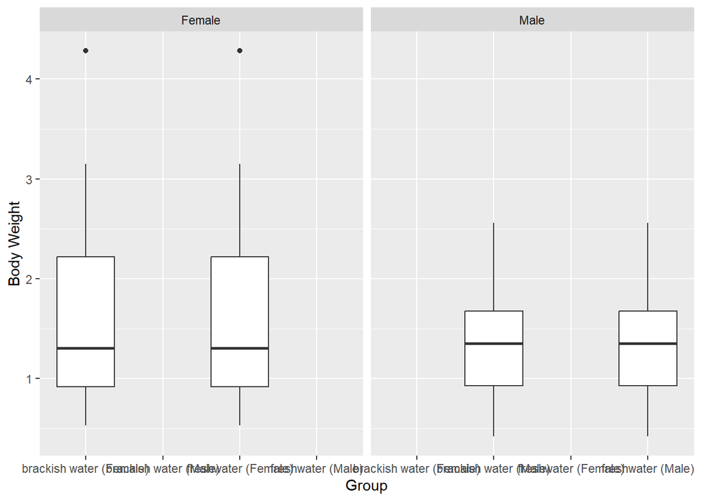

```r
# ggplot2

ggplot(data, aes(x = Group, y =Value)) +
  geom_boxplot() +
  ylab("Body Weight") +
  xlab("Group") +
  facet_wrap(~ Sex)
```

## Wilcoxon test

Wilcoxon test was performed in order to test the hypothesis whether there are statistically significant differences between body length and sex.

```r
#Compare female mean length in brackish and freshwater using the Wilcoxon rank sum exact test

mean_length_female_brackish <- mean(SampleInfo$Length.cm.[SampleInfo$Site %in% c("L01","L02","L03","L05") & SampleInfo$Sex == "F"])
mean_length_female_fresh <- mean(SampleInfo$Length.cm.[SampleInfo$Site %in% c("L07","L09","L10","L12") & SampleInfo$Sex == "F"])


#Compare male mean length

mean_length_male_brackish <- mean(SampleInfo$Length.cm.[SampleInfo$Site %in% c("L01","L02","L03","L05") & SampleInfo$Sex == "M"])
mean_length_male_fresh <-  mean(SampleInfo$Length.cm.[SampleInfo$Site %in% c("L07","L09","L10","L12") & SampleInfo$Sex == "M"])
```

```r
# Wilcox test comparison between males (M) vs habitat (H) and females (F) Vs habitat (H)
resultHM <- wilcox.test(mean_length_male_brackish, mean_length_male_fresh)
resultHM
```

```
##
##  Wilcoxon rank sum exact test
##
## data:  mean_length_male_brackish and mean_length_male_fresh
## W = 0, p-value = 1
## alternative hypothesis: true location shift is not equal to 0
```

```r
resultHF <- wilcox.test(mean_length_female_brackish, mean_length_female_fresh)
resultHF
```

```
##
##  Wilcoxon rank sum exact test
##
## data:  mean_length_female_brackish and mean_length_female_fresh
## W = 0, p-value = 1
## alternative hypothesis: true location shift is not equal to 0
```

```r
# Wilcox test comparison between males (M) vs females (F) in two different habitats (B= Brackish, F=Freshwater)

resultFM_B <- wilcox.test(mean_length_male_brackish, mean_length_female_brackish)
resultFM_B
```

```
##
##  Wilcoxon rank sum exact test
##
## data:  mean_length_male_brackish and mean_length_female_brackish
## W = 0, p-value = 1
## alternative hypothesis: true location shift is not equal to 0
```

```r
resultFM_F <- wilcox.test(mean_length_male_fresh, mean_length_female_fresh)
resultFM_F
```

```
##
##  Wilcoxon rank sum exact test
##
## data:  mean_length_male_fresh and mean_length_female_fresh
## W = 0, p-value = 1
## alternative hypothesis: true location shift is not equal to 0
```

All four Wilcox tests state the same result of p-value=1 which means that there are no statistically significant differences between sex and habitat. Hence, for this experiment the data show that each sex’s body length is not affected differently for each habitat (Brackish or Freshwater).

Wilcoxon test was performed in order to test the hypothesis whether there are statistically significant differences between body weight and sex.

```r
# Compare female mean body weight in brackish and freshwater using the Wilcoxon rank sum exact test
mean_bodyweight_female_brackish <- mean(SampleInfo$Body_weight.g.[SampleInfo$Site %in% c("L01","L02","L03","L05") & SampleInfo$Sex == "F"])
mean_bodyweight_female_fresh <- mean(SampleInfo$Body_weight.g.[SampleInfo$Site %in% c("L07","L09","L10","L12") & SampleInfo$Sex == "F"])

# Compare male mean body weight
mean_bodyweight_male_brackish <- mean(SampleInfo$Body_weight.g.[SampleInfo$Site %in% c("L01","L02","L03","L05") & SampleInfo$Sex == "M"])
mean_bodyweight_male_fresh <- mean(SampleInfo$Body_weight.g.[SampleInfo$Site %in% c("L07","L09","L10","L12") & SampleInfo$Sex == "M"])
```

```r
# Wilcox test comparison between male bodyweight (M) vs habitat (H) and female bodyweight (F) vs habitat (H)
resultHM_bodyweight <- wilcox.test(mean_bodyweight_male_brackish, mean_bodyweight_male_fresh)
resultHM_bodyweight
```

```
##
##  Wilcoxon rank sum exact test
##
## data:  mean_bodyweight_male_brackish and mean_bodyweight_male_fresh
## W = 0, p-value = 1
## alternative hypothesis: true location shift is not equal to 0
```

From the wilcox test, the p-value is equal to 1, which means that there are no statistically significant differences.

# Do environmental parameters (eg mean temperature) affect body weight and body length based on each habitat or site?

According to the supplementary tables of the manuscript, there are variables like distance from the shore (in km), salinity, depth (cm) and pH values. Data for the mean temperature across the four seasons (spring 2008, fall 2008, spring 2009 and summer 2009) is not available.

I managed to find some information regarding the mean temperature across the four seasons that the experiment took place. I used the aquastat tool from fao.org.

Hence, we can compare the impact of mean temperature on body length and body weight.I compared bodyweight and bodylength of three spined individuals for the seasons:

1. Spring 2008 vs Spring 2009
2. Fall 2008 vs Summer 2009

## Body length~ Mean temperature

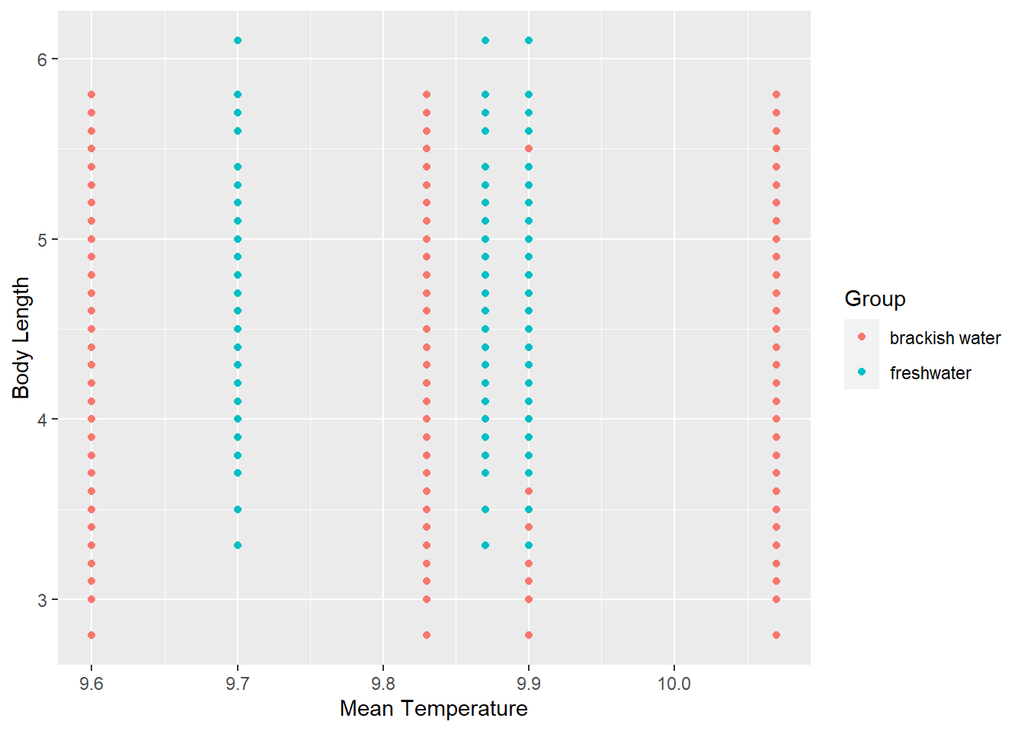

```r
brackish_sites <- c("L01", "L02", "L03", "L05")
fresh_sites <- c("L07", "L09", "L10", "L12")


brackish_length <- SampleInfo$Length.cm.[SampleInfo$Site %in% brackish_sites]
fresh_length <- SampleInfo$Length.cm.[SampleInfo$Site %in% fresh_sites]


brackish_temperature_s2008 <- rep(SitesInfo_new$spring_2008[SitesInfo_new$Site %in% brackish_sites], each = length(brackish_length))
fresh_temperature_s2008 <- rep(SitesInfo_new$spring_2008[SitesInfo_new$Site %in% fresh_sites], each = length(fresh_length))
brackish_temperature_s2009 <- rep(SitesInfo_new$spring_2009[SitesInfo_new$Site %in% brackish_sites], each = length(brackish_length))
fresh_temperature_s2009 <- rep(SitesInfo_new$spring_2009[SitesInfo_new$Site %in% fresh_sites], each = length(fresh_length))
brackish_temperature_f2008 <- rep(SitesInfo_new$fall_2008[SitesInfo_new$Site %in% brackish_sites], each = length(brackish_length))
fresh_temperature_f2008 <- rep(SitesInfo_new$fall_2008[SitesInfo_new$Site %in% fresh_sites], each = length(fresh_length))
brackish_temperature_sum2009 <- rep(SitesInfo_new$summer_2009[SitesInfo_new$Site %in% brackish_sites], each = length(brackish_length))
fresh_temperature_sum2009 <- rep(SitesInfo_new$summer_2009[SitesInfo_new$Site %in% fresh_sites], each = length(fresh_length))


data <- data.frame(
  Group = factor(c(rep("brackish water", length(brackish_length)), rep("freshwater", length(fresh_length)))),
  Value = c(brackish_length, fresh_length),
  Temperature = c(
    brackish_temperature_s2008,
    #fresh_temperature_s2008,
    brackish_temperature_s2009
    #fresh_temperature_s2009
    #brackish_temperature_f2008
    #fresh_temperature_f2008,
    #brackish_temperature_sum2009,
    #fresh_temperature_sum2009
  )
)

# ggplot2 - Scatter plot for body length with mean temperature
ggplot(data, aes(x = Temperature, y = Value, color = Group)) +
  geom_point() +
  ylab("Body Length") +
  xlab("Mean Temperature")
```

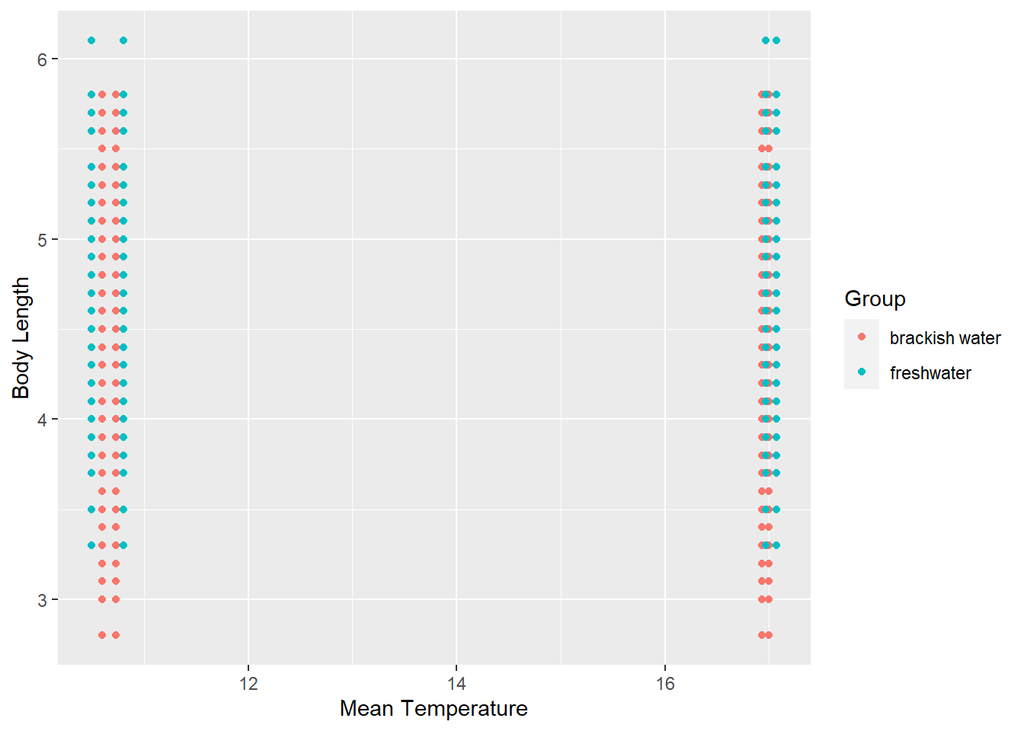

```r
data <- data.frame(
  Group = factor(c(rep("brackish water", length(brackish_length)), rep("freshwater", length(fresh_length)))),
  Value = c(brackish_length, fresh_length),
  Temperature = c(
    fresh_temperature_f2008,
    fresh_temperature_sum2009
  )
)

# ggplot2 - Scatter plot for body length with mean temperature
ggplot(data, aes(x = Temperature, y = Value, color = Group)) +
  geom_point() +
  ylab("Body Length") +
  xlab("Mean Temperature")
```

It seems that the temperature changes between seasons do not affect the body length.

### Body weight~mean temperature

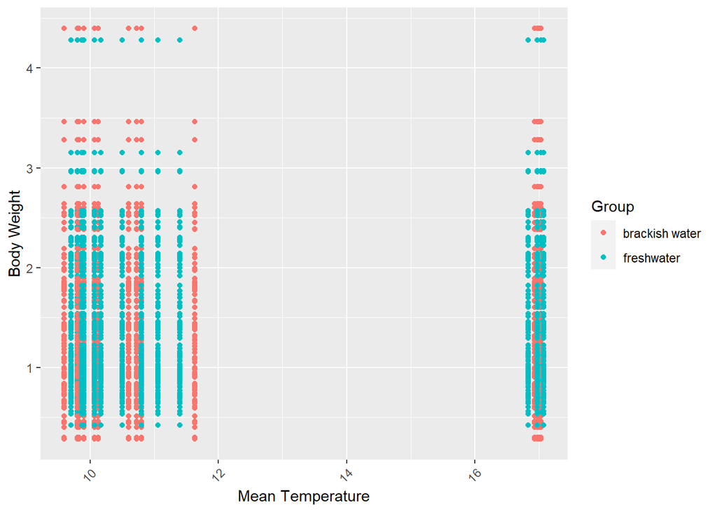

```r
brackish_weight <- SampleInfo$Body_weight.g.[SampleInfo$Site %in% brackish_sites]
fresh_weight <- SampleInfo$Body_weight.g.[SampleInfo$Site %in% fresh_sites]


brackish_temperature_s2008 <- rep(SitesInfo_new$spring_2008[SitesInfo_new$Site %in% brackish_sites], each = length(brackish_weight))
fresh_temperature_s2008 <- rep(SitesInfo_new$spring_2008[SitesInfo_new$Site %in% fresh_sites], each = length(fresh_weight))
brackish_temperature_s2009 <- rep(SitesInfo_new$spring_2009[SitesInfo_new$Site %in% brackish_sites], each = length(brackish_weight))
fresh_temperature_s2009 <- rep(SitesInfo_new$spring_2009[SitesInfo_new$Site %in% fresh_sites], each = length(fresh_weight))
brackish_temperature_f2008 <- rep(SitesInfo_new$fall_2008[SitesInfo_new$Site %in% brackish_sites], each = length(brackish_weight))
fresh_temperature_f2008 <- rep(SitesInfo_new$fall_2008[SitesInfo_new$Site %in% fresh_sites], each = length(fresh_weight))
brackish_temperature_sum2009 <- rep(SitesInfo_new$summer_2009[SitesInfo_new$Site %in% brackish_sites], each = length(brackish_weight))
fresh_temperature_sum2009 <- rep(SitesInfo_new$summer_2009[SitesInfo_new$Site %in% fresh_sites], each = length(fresh_weight))


data <- data.frame(
  Group = factor(c(rep("brackish water", length(brackish_weight)), rep("freshwater", length(fresh_weight)))),
  Value = c(brackish_weight, fresh_weight),
  Temperature = c(
    brackish_temperature_s2008,
    fresh_temperature_s2008,
    brackish_temperature_s2009,
    fresh_temperature_s2009,
    brackish_temperature_f2008,
    fresh_temperature_f2008,
    brackish_temperature_sum2009,
    fresh_temperature_sum2009
  )
)

# ggplot2 - Scatter plot for body length with mean temperature
ggplot(data, aes(x = Temperature, y = Value, color = Group)) +
  geom_point() +
  ylab("Body Weight") +
  xlab("Mean Temperature")+
   theme(axis.text.x = element_text(angle = 45, hjust = 1))
```

### Bodyweight~Spring 2008 vs Spring 2009

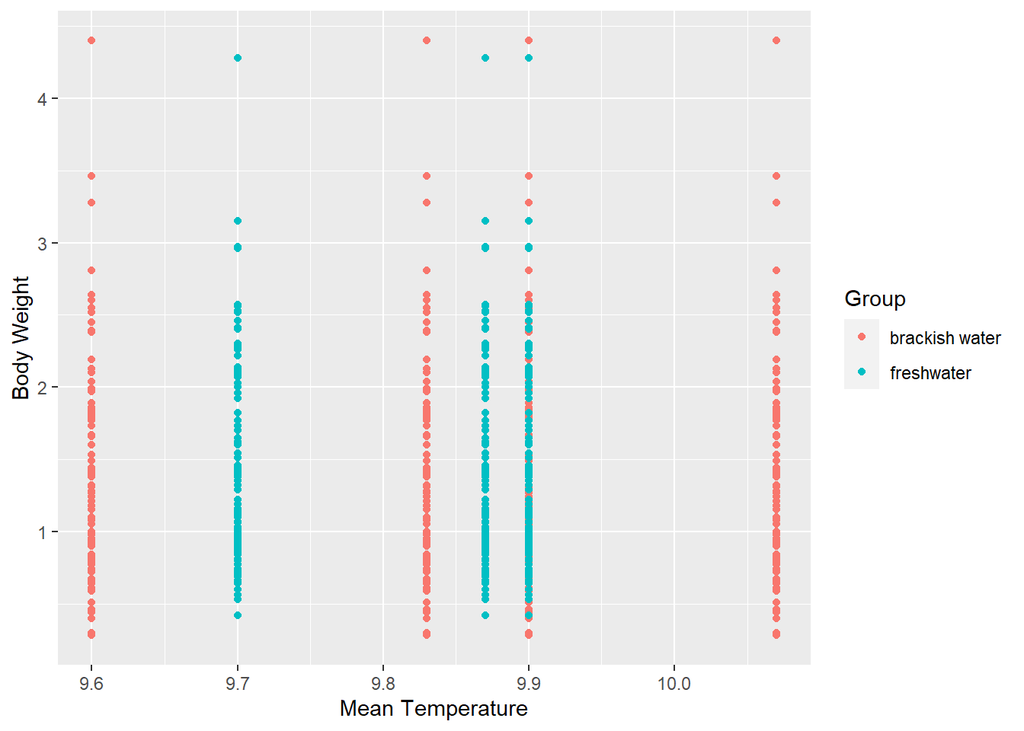

```r
data <- data.frame(
  Group = factor(c(rep("brackish water", length(brackish_weight)), rep("freshwater", length(fresh_weight)))),
  Value = c(brackish_weight, fresh_weight),
  Temperature = c(
    brackish_temperature_s2008,
    brackish_temperature_s2009
  )
)

# ggplot2 - Scatter plot for body length with mean temperature
ggplot(data, aes(x = Temperature, y = Value, color = Group)) +
  geom_point() +
  ylab("Body Weight") +
  xlab("Mean Temperature")
```

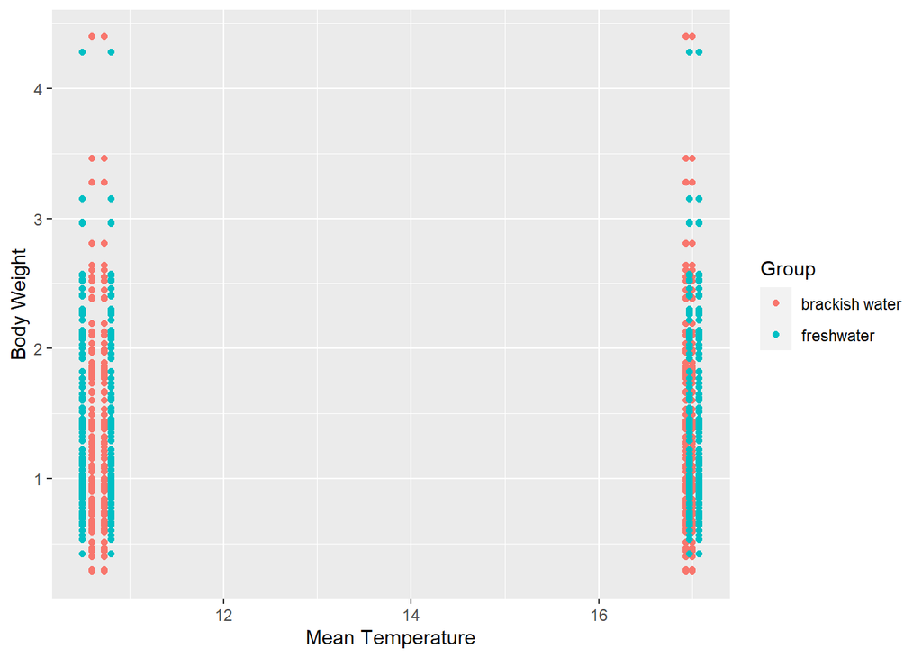

```r
data <- data.frame(
  Group = factor(c(rep("brackish water", length(brackish_weight)), rep("freshwater", length(fresh_weight)))),
  Value = c(brackish_weight, fresh_weight),
  Temperature = c(
    fresh_temperature_f2008,
    fresh_temperature_sum2009
  )
)

# ggplot2 - Scatter plot for body length with mean temperature
ggplot(data, aes(x = Temperature, y = Value, color = Group)) +
  geom_point() +
  ylab("Body Weight") +
  xlab("Mean Temperature")
```

It seems that there is no correlation between the body weight and the mean temperature.

# Results

After the analysis of 192 Gasterosteus Aculeatus individuals, a comparison between the genome of the 192 individuals and that of the reference genome was conducted. Moreover, the differences between the populations of two different habitats were compared.

# References

Hu, J., & Barrett, R. D. H. (2023). The role of plastic and evolved DNA methylation in parallel adaptation of threespine stickleback (Gasterosteus aculeatus). *Molecular Ecology*, *32*(7), 1581–1591. https://doi.org/10.1111/mec.16832

Kemppainen, P., Li, Z., Rastas, P., Löytynoja, A., Fang, B., Yang, J., Guo, B., Shikano, T., & Merilä, J. (2021). Genetic population structure constrains local adaptation in sticklebacks. *Molecular Ecology*, *30*(9), 1946–1961. https://doi.org/10.1111/mec.15808

Meek, M. H., Beever, E. A., Barbosa, S., Fitzpatrick, S. W., Fletcher, N. K., Mittan-Moreau, C. S., Reid, B. N., Campbell-Staton, S. C., Green, N. F., & Hellmann, J. J. (2023). Understanding Local Adaptation to Prepare Populations for Climate Change. *BioScience*, *73*(1), 36–47. https://doi.org/10.1093/biosci/biac101

Raeymaekers, J. A. M., Chaturvedi, A., Hablützel, P. I., Verdonck, I., Hellemans, B., Maes, G. E., de Meester, L., & Volckaert, F. A. M. (2017). Adaptive and non-adaptive divergence in a common landscape. *Nature Communications*, *8*(1). https://doi.org/10.1038/s41467-017-00256-6

Tusso, S., Nieuwenhuis, B. P. S., Weissensteiner, B., Immler, S., & Wolf, J. B. W. (2021). Experimental evolution of adaptive divergence under varying degrees of gene flow. *Nature Ecology and Evolution*, *5*(3), 338–349. https://doi.org/10.1038/s41559-020-01363-2